# Palmer Archipelago (Antarctica) penguin data

We will be using the same dataset through our discussions on classification with tree-methods (Decision Tree,Random Forests, and Gradient Boosted Trees) in order to compare performance metrics across these related models.

We will work with the "Palmer Penguins" dataset, as it is simple enough to help us fully understand how changing hyperparameters can change classification results.

Data were collected and made available by Dr. Kristen Gorman and the Palmer Station, Antarctica LTER, a member of the Long Term Ecological Research Network.

Gorman KB, Williams TD, Fraser WR (2014) Ecological Sexual Dimorphism and Environmental Variability within a Community of Antarctic Penguins (Genus Pygoscelis). PLoS ONE 9(3): e90081. doi:10.1371/journal.pone.0090081

## Index

- 1. Importing Libraries and Dataset
- 1. Exploratory Data Analysis
- 1. Visiluazation of the dataset
- 1. Feature Engineering
- 1. Decision tree model building
- 1. Hyperparameter tuning in DT
- 1. Random Forest
- 1. Hyperparameter tuning in random forest

## 1. Importing Libraries and Dataset

```python
# Importing required libraries
import numpy as np
import pandas as pd
import matplotlib.pyplot as plt
import seaborn as sns
%matplotlib inline


import sklearn
from sklearn.preprocessing import LabelEncoder
from sklearn.model_selection import train_test_split
from sklearn.tree import DecisionTreeClassifier
from sklearn.tree import plot_tree
from sklearn.metrics import confusion_matrix, accuracy_score
from sklearn.model_selection import GridSearchCV
```

```python
# Setting up the theme
sns.set_style('darkgrid')
```

```python
# importing warnings
import warnings
warnings.filterwarnings('ignore')
```

```python
# Import dataset through pandas
df = pd.read_csv('penguins_size.csv')
df.head()
```

|  | species | island | culmen_length_mm | culmen_depth_mm | flipper_length_mm | body_mass_g | sex |
| --- | --- | --- | --- | --- | --- | --- | --- |
| 0 | Adelie | Torgersen | 39.1 | 18.7 | 181.0 | 3750.0 | MALE |
| 1 | Adelie | Torgersen | 39.5 | 17.4 | 186.0 | 3800.0 | FEMALE |
| 2 | Adelie | Torgersen | 40.3 | 18.0 | 195.0 | 3250.0 | FEMALE |
| 3 | Adelie | Torgersen | NaN | NaN | NaN | NaN | NaN |
| 4 | Adelie | Torgersen | 36.7 | 19.3 | 193.0 | 3450.0 | FEMALE |

penguins_size.csv: Simplified data from original penguin data sets. Contains variables:

- species: penguin species (Chinstrap, Adélie, or Gentoo)
- culmen_length_mm: culmen length (mm)
- culmen_depth_mm: culmen depth (mm)
- flipper_length_mm: flipper length (mm)
- body_mass_g: body mass (g)
- island: island name (Dream, Torgersen, or Biscoe) in the Palmer Archipelago (Antarctica)
- sex: penguin sex

```python
# Checking Dataset
df.info()
```

```
<class 'pandas.core.frame.DataFrame'>
RangeIndex: 344 entries, 0 to 343
Data columns (total 7 columns):
 #   Column             Non-Null Count  Dtype
---  ------             --------------  -----
 0   species            344 non-null    object
 1   island             344 non-null    object
 2   culmen_length_mm   342 non-null    float64
 3   culmen_depth_mm    342 non-null    float64
 4   flipper_length_mm  342 non-null    float64
 5   body_mass_g        342 non-null    float64
 6   sex                334 non-null    object
dtypes: float64(4), object(3)
memory usage: 18.9+ KB
```

## 2. Exploratory Data Analysis

```python
# Checking null values present in the dataset
df.isnull().sum()
```

```
species               0
island                0
culmen_length_mm      2
culmen_depth_mm       2
flipper_length_mm     2
body_mass_g           2
sex                  10
dtype: int64
```

```python
# percentage null values present in dataset
round(df.isnull().sum()/len(df)*100,2)
```

```
species              0.00
island               0.00
culmen_length_mm     0.58
culmen_depth_mm      0.58
flipper_length_mm    0.58
body_mass_g          0.58
sex                  2.91
dtype: float64
```

```python
# Dropping the null values
df.dropna(inplace=True)
```

```python
# crosscheck
df.isnull().sum()
```

```
species              0
island               0
culmen_length_mm     0
culmen_depth_mm      0
flipper_length_mm    0
body_mass_g          0
sex                  0
dtype: int64
```

```python
# Checking records against the species
df.species.value_counts()
```

```
Adelie       146
Gentoo       120
Chinstrap     68
Name: species, dtype: int64
```

```python
# checking records against each categorical variables
for col in df.columns:
    print('-'*40)
    print(df[col].value_counts())
```

```
----------------------------------------
Adelie       146
Gentoo       120
Chinstrap     68
Name: species, dtype: int64
----------------------------------------
Biscoe       164
Dream        123
Torgersen     47
Name: island, dtype: int64
----------------------------------------
41.1    7
45.2    6
50.5    5
39.6    5
45.5    5
       ..
35.6    1
37.5    1
36.8    1
43.1    1
49.9    1
Name: culmen_length_mm, Length: 163, dtype: int64
----------------------------------------
17.0    12
18.5    10
17.9    10
15.0    10
18.6    10
        ..
20.1     1
20.6     1
14.9     1
13.2     1
20.8     1
Name: culmen_depth_mm, Length: 79, dtype: int64
----------------------------------------
190.0    21
195.0    17
187.0    16
```

[output cut: 55 more lines]

```
3700.0    10
3950.0    10
3550.0     9
          ..
3975.0     1
3575.0     1
3850.0     1
2700.0     1
5750.0     1
Name: body_mass_g, Length: 93, dtype: int64
----------------------------------------
MALE      168
FEMALE    165
.           1
Name: sex, dtype: int64
```

- there is one '.' entry in sex column replaceing it with the male column (Mode) as the orignal dataset is small

```python
# Taking false entry
df[df.sex == '.']
```

|  | species | island | culmen_length_mm | culmen_depth_mm | flipper_length_mm | body_mass_g | sex |
| --- | --- | --- | --- | --- | --- | --- | --- |
| 336 | Gentoo | Biscoe | 44.5 | 15.7 | 217.0 | 4875.0 | . |

```python
# replacing . with the mode of the column
mo = df.sex.mode()

df.sex.replace('.', mo[0], inplace=True)
```

```python
# cross check
df.sex.value_counts()
```

```
MALE      169
FEMALE    165
Name: sex, dtype: int64
```

## 3. Visiluazation of the dataset

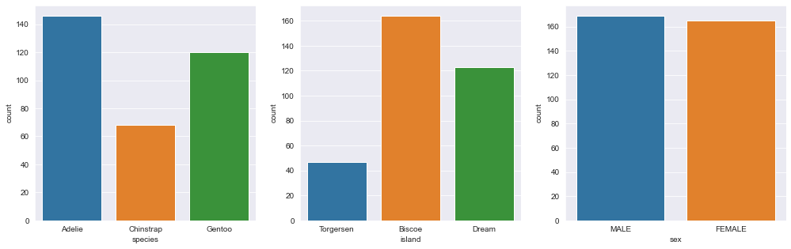

```python
# Categorical Variables
plt.figure(figsize=(17,5))
plt.subplot(1,3,1)
sns.countplot(x = df.species, data = df)
plt.subplot(1,3,2)
sns.countplot(x = df.island, data = df)
plt.subplot(1,3,3)
sns.countplot(x = df.sex, data = df)
plt.show()
```

```python
# description of numerical variables
df.describe()
```

|  | culmen_length_mm | culmen_depth_mm | flipper_length_mm | body_mass_g |
| --- | --- | --- | --- | --- |
| count | 334.000000 | 334.000000 | 334.000000 | 334.000000 |
| mean | 43.994311 | 17.160479 | 201.014970 | 4209.056886 |
| std | 5.460521 | 1.967909 | 14.022175 | 804.836129 |
| min | 32.100000 | 13.100000 | 172.000000 | 2700.000000 |
| 25% | 39.500000 | 15.600000 | 190.000000 | 3550.000000 |
| 50% | 44.500000 | 17.300000 | 197.000000 | 4050.000000 |
| 75% | 48.575000 | 18.700000 | 213.000000 | 4793.750000 |
| max | 59.600000 | 21.500000 | 231.000000 | 6300.000000 |

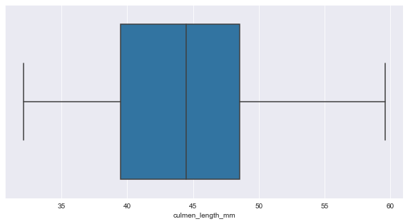

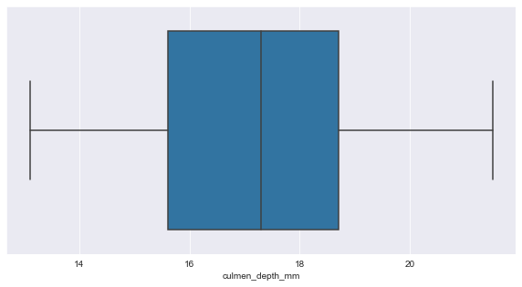

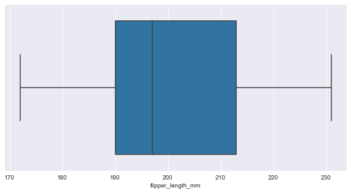

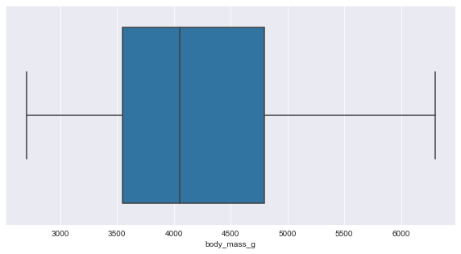

```python
# Checking for distribution of numeric variables
n_var = ['culmen_length_mm', 'culmen_depth_mm', 'flipper_length_mm', 'body_mass_g']

for i in n_var:
    plt.figure(figsize=(10,5))
    sns.boxplot(df[i])
```

- the dataset is free of outliers

```python
# Checking for the correlation between the variables
df.corr()
```

|  | culmen_length_mm | culmen_depth_mm | flipper_length_mm | body_mass_g |
| --- | --- | --- | --- | --- |
| culmen_length_mm | 1.000000 | -0.228640 | 0.652126 | 0.589066 |
| culmen_depth_mm | -0.228640 | 1.000000 | -0.578730 | -0.472987 |
| flipper_length_mm | 0.652126 | -0.578730 | 1.000000 | 0.873211 |
| body_mass_g | 0.589066 | -0.472987 | 0.873211 | 1.000000 |

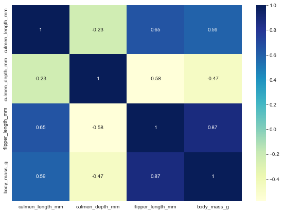

```python
# plotting the heatmap
plt.figure(figsize=(10,7))
sns.heatmap(df.corr(), annot=True, cmap="YlGnBu");
```

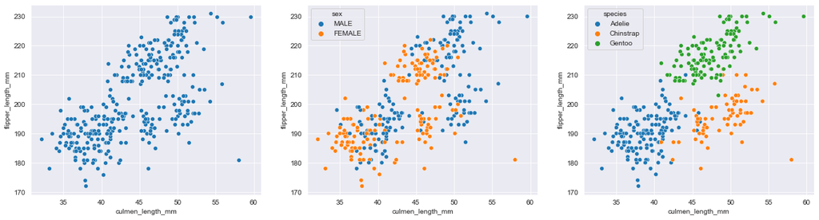

```python
# plotting scatter plot between the culmen_length_mm and flipper_length_mm variables
plt.figure(figsize=(20,5))
plt.subplot(1,3,1)
sns.scatterplot(x ='culmen_length_mm' , y = 'flipper_length_mm', data= df)
plt.subplot(1,3,2)
sns.scatterplot(x ='culmen_length_mm' , y = 'flipper_length_mm', data= df, hue= 'sex')
plt.subplot(1,3,3)
sns.scatterplot(x ='culmen_length_mm' , y = 'flipper_length_mm', data= df, hue= 'species');
```

```python
df.head()
```

|  | species | island | culmen_length_mm | culmen_depth_mm | flipper_length_mm | body_mass_g | sex |
| --- | --- | --- | --- | --- | --- | --- | --- |
| 0 | Adelie | Torgersen | 39.1 | 18.7 | 181.0 | 3750.0 | MALE |
| 1 | Adelie | Torgersen | 39.5 | 17.4 | 186.0 | 3800.0 | FEMALE |
| 2 | Adelie | Torgersen | 40.3 | 18.0 | 195.0 | 3250.0 | FEMALE |
| 4 | Adelie | Torgersen | 36.7 | 19.3 | 193.0 | 3450.0 | FEMALE |
| 5 | Adelie | Torgersen | 39.3 | 20.6 | 190.0 | 3650.0 | MALE |

## 4. Feature Engineering

```python
# Ckecking variables which will be used for label encoding
df.species.unique()
```

```
array(['Adelie', 'Chinstrap', 'Gentoo'], dtype=object)
```

```python
# Initalization of the label encoder
le = LabelEncoder()
```

```python
# Fitting on species column
df.species = le.fit_transform(df.species)
```

```python
df.species.unique()
```

```
array([0, 1, 2])
```

```python
# Creating dummay variables for the multiple categorical variables
df1 = pd.get_dummies(df[['island', 'sex']],
                    prefix = ['island', 'sex'], drop_first=True )
```

```python
# concatenating the dummy variables to the orignal datasets
ndf = pd.concat([df, df1], axis=1)
```

```python
ndf.head()
```

|  | species | island | culmen_length_mm | culmen_depth_mm | flipper_length_mm | body_mass_g | sex | island_Dream | island_Torgersen | sex_MALE |
| --- | --- | --- | --- | --- | --- | --- | --- | --- | --- | --- |
| 0 | 0 | Torgersen | 39.1 | 18.7 | 181.0 | 3750.0 | MALE | 0 | 1 | 1 |
| 1 | 0 | Torgersen | 39.5 | 17.4 | 186.0 | 3800.0 | FEMALE | 0 | 1 | 0 |
| 2 | 0 | Torgersen | 40.3 | 18.0 | 195.0 | 3250.0 | FEMALE | 0 | 1 | 0 |
| 4 | 0 | Torgersen | 36.7 | 19.3 | 193.0 | 3450.0 | FEMALE | 0 | 1 | 0 |
| 5 | 0 | Torgersen | 39.3 | 20.6 | 190.0 | 3650.0 | MALE | 0 | 1 | 1 |

```python
# Dropping the column with orignal dataset
ndf.drop(['island', 'sex'], axis = 1, inplace = True)
```

```python
ndf.head()
```

|  | species | culmen_length_mm | culmen_depth_mm | flipper_length_mm | body_mass_g | island_Dream | island_Torgersen | sex_MALE |
| --- | --- | --- | --- | --- | --- | --- | --- | --- |
| 0 | 0 | 39.1 | 18.7 | 181.0 | 3750.0 | 0 | 1 | 1 |
| 1 | 0 | 39.5 | 17.4 | 186.0 | 3800.0 | 0 | 1 | 0 |
| 2 | 0 | 40.3 | 18.0 | 195.0 | 3250.0 | 0 | 1 | 0 |
| 4 | 0 | 36.7 | 19.3 | 193.0 | 3450.0 | 0 | 1 | 0 |
| 5 | 0 | 39.3 | 20.6 | 190.0 | 3650.0 | 0 | 1 | 1 |

## 5. Decision tree model building

```python
# Defining the x and y variables
X = ndf.drop('species', axis= 1)
y = ndf['species']
```

```python
# Splitting hte dataset into train and test sets
X_train, X_test, y_train, y_test = train_test_split(X, y, train_size=0.7, random_state= 100)
```

```python
# Initalization of the decisiontreeclassifier
dtc = DecisionTreeClassifier()
```

```python
# fitting on model
dtc.fit(X_train, y_train)
```

```
DecisionTreeClassifier()
```

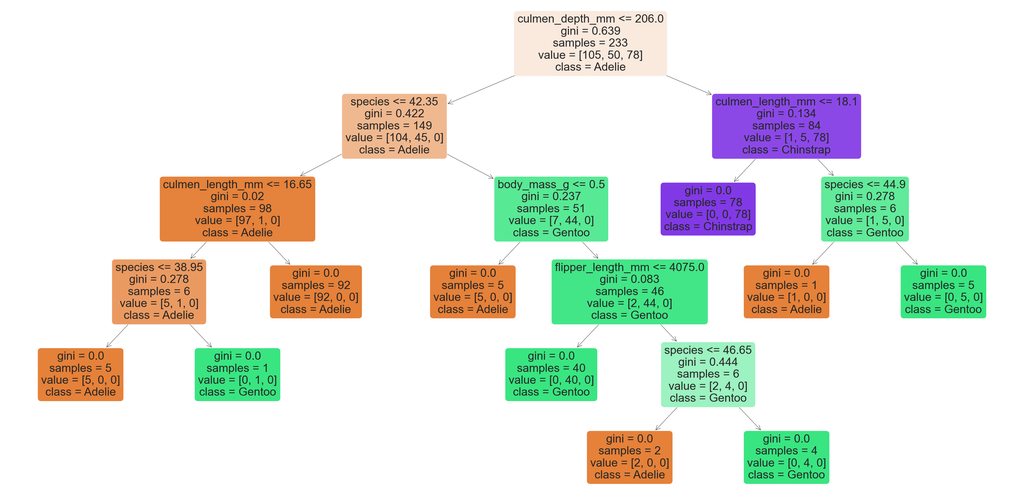

```python
# Building initial model
plt.figure(figsize=(60, 30))
plot_tree(dtc, feature_names= ndf.columns, class_names= ['Adelie','Gentoo','Chinstrap'], filled= True, rounded = True )
plt.show()
```

```python
# Model prediction
y_train_pred = dtc.predict(X_train)
y_test_pred = dtc.predict(X_test)
```

```python
# checking accuracy on train data

print(accuracy_score(y_train, y_train_pred))
confusion_matrix(y_train, y_train_pred)
```

```
1.0
```

```
array([[105,   0,   0],
       [  0,  50,   0],
       [  0,   0,  78]], dtype=int64)
```

```python
# checking accuracy on test data
print(accuracy_score(y_test, y_test_pred))
confusion_matrix(y_test, y_test_pred)
```

```
0.9702970297029703
```

```
array([[40,  0,  1],
       [ 1, 17,  0],
       [ 1,  0, 41]], dtype=int64)
```

## 6. Hyperparameter tuning in DT

```python
# Creating the user defined function for tree plotting
def get_dt(data):
    plt.figure(figsize=(60,30))
    plot_tree(data, feature_names= ndf.columns, class_names= ['Adelie','Gentoo','Chinstrap'], filled= True, rounded = True)
    plt.show()
```

```python
# Creating the user defined function for model evaluation
def eval_mat(data):
    y_train_pred = data.predict(X_train)
    y_test_pred = data.predict(X_test)
    print("Train Performance")
    print(accuracy_score(y_train, y_train_pred))
    print(confusion_matrix(y_train, y_train_pred))
    print("Test Performance")
    print(accuracy_score(y_test, y_test_pred))
    print(confusion_matrix(y_test, y_test_pred))
```

```python
# hyperparametr tuning using GridSearhCV
dt = DecisionTreeClassifier(random_state=100)
```

```python
# Defining parameters for the hyperparameters
params = {
    'max_depth': [2,3,5],
    'min_samples_leaf': [5,10,15,20,25],
    'criterion': ['gini', 'entropy']
}
```

```python
# creating model through GridSearchCV
grid_search= GridSearchCV(estimator= dt, param_grid = params, cv= 4, n_jobs=-1, verbose=1, scoring= 'accuracy')
```

```python
# model fitting
grid_search.fit(X_train, y_train)
```

```
Fitting 4 folds for each of 30 candidates, totalling 120 fits
```

```
GridSearchCV(cv=4, estimator=DecisionTreeClassifier(random_state=100),
             n_jobs=-1,
             param_grid={'criterion': ['gini', 'entropy'],
                         'max_depth': [2, 3, 5],
                         'min_samples_leaf': [5, 10, 15, 20, 25]},
             scoring='accuracy', verbose=1)
```

```python
# Checking out the results

grid_search.cv_results_
```

[output not shown]

[output cut: 70 more lines]

[output not shown]

```python
# Creating the dataframe with result
cv_df = pd.DataFrame(grid_search.cv_results_)
cv_df.head()
```

|  | mean_fit_time | std_fit_time | mean_score_time | std_score_time | param_criterion | param_max_depth | param_min_samples_leaf | params | split0_test_score | split1_test_score | split2_test_score | split3_test_score | mean_test_score | std_test_score | rank_test_score |
| --- | --- | --- | --- | --- | --- | --- | --- | --- | --- | --- | --- | --- | --- | --- | --- |
| 0 | 0.005746 | 0.000433 | 0.002998 | 5.462856e-07 | gini | 2 | 5 | {'criterion': 'gini', 'max_depth': 2, 'min_sam... | 0.915254 | 0.948276 | 0.896552 | 0.862069 | 0.905538 | 0.03119 | 5 |
| 1 | 0.004498 | 0.000499 | 0.003997 | 2.343691e-03 | gini | 2 | 10 | {'criterion': 'gini', 'max_depth': 2, 'min_sam... | 0.898305 | 0.948276 | 0.896552 | 0.862069 | 0.901300 | 0.03073 | 7 |
| 2 | 0.004248 | 0.000433 | 0.003998 | 2.343996e-03 | gini | 2 | 15 | {'criterion': 'gini', 'max_depth': 2, 'min_sam... | 0.898305 | 0.948276 | 0.896552 | 0.862069 | 0.901300 | 0.03073 | 7 |
| 3 | 0.005247 | 0.001089 | 0.003748 | 1.297705e-03 | gini | 2 | 20 | {'criterion': 'gini', 'max_depth': 2, 'min_sam... | 0.898305 | 0.948276 | 0.896552 | 0.862069 | 0.901300 | 0.03073 | 7 |
| 4 | 0.006247 | 0.002163 | 0.002498 | 4.998446e-04 | gini | 2 | 25 | {'criterion': 'gini', 'max_depth': 2, 'min_sam... | 0.898305 | 0.948276 | 0.896552 | 0.862069 | 0.901300 | 0.03073 | 7 |

```python
# Shape of the result
cv_df.shape
```

```
(30, 15)
```

```python
# Best parameters
grid_search.best_estimator_
```

```
DecisionTreeClassifier(max_depth=5, min_samples_leaf=5, random_state=100)
```

```python
# Best score
grid_search.best_score_
```

```
0.9439655172413793
```

```python
# best parameters
grid_search.best_params_
```

```
{'criterion': 'gini', 'max_depth': 5, 'min_samples_leaf': 5}
```

```python
# Taking out the best parameters for the model building
dt_best = grid_search.best_estimator_
```

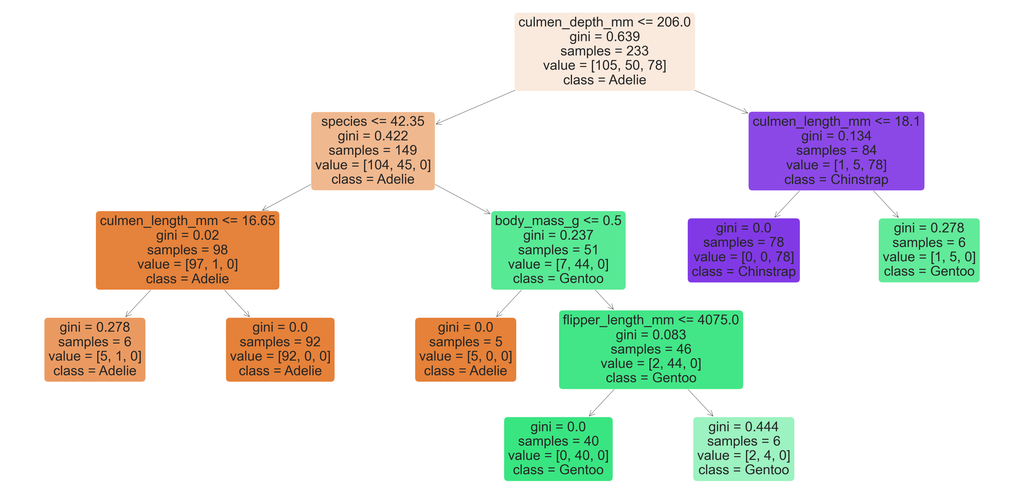

```python
# Draw the decision tree
get_dt(dt_best)
```

```python
# Checking for the accuracy score
eval_mat(dt_best)
```

```
Train Performance
0.9828326180257511
[[102   3   0]
 [  1  49   0]
 [  0   0  78]]
Test Performance
0.9801980198019802
[[40  0  1]
 [ 0 18  0]
 [ 1  0 41]]
```

## 7. Random Forest

```python
# Import library

from sklearn.ensemble import RandomForestClassifier
```

```python
X_train.head()
```

|  | culmen_length_mm | culmen_depth_mm | flipper_length_mm | body_mass_g | island_Dream | island_Torgersen | sex_MALE |
| --- | --- | --- | --- | --- | --- | --- | --- |
| 279 | 50.4 | 15.3 | 224.0 | 5550.0 | 0 | 0 | 1 |
| 138 | 37.0 | 16.5 | 185.0 | 3400.0 | 1 | 0 | 0 |
| 45 | 39.6 | 18.8 | 190.0 | 4600.0 | 1 | 0 | 1 |
| 270 | 46.6 | 14.2 | 210.0 | 4850.0 | 0 | 0 | 0 |
| 37 | 42.2 | 18.5 | 180.0 | 3550.0 | 1 | 0 | 0 |

```python
y_train.head()
```

```
279    2
138    0
45     0
270    2
37     0
Name: species, dtype: int32
```

```python
rf = RandomForestClassifier(random_state=42, max_depth= 4, n_estimators = 10,)
rf
```

```
RandomForestClassifier(max_depth=4, n_estimators=10, random_state=42)
```

```python
rf.fit(X_train, y_train)
```

```
RandomForestClassifier(max_depth=4, n_estimators=10, random_state=42)
```

```python
sample_tree = rf.estimators_[0]  # taking ist estimator
```

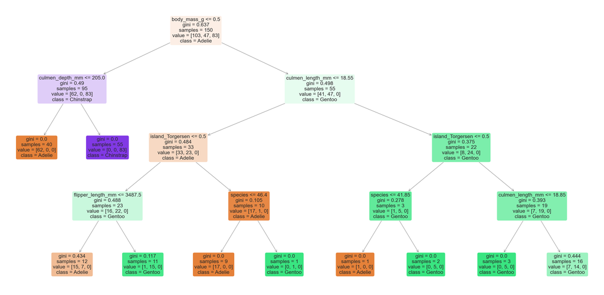

```python
get_dt(sample_tree)
```

```python
# Checking for the accuracy score
eval_mat(sample_tree)
```

```
Train Performance
0.8884120171673819
[[90 15  0]
 [11 39  0]
 [ 0  0 78]]
Test Performance
0.9306930693069307
[[36  4  1]
 [ 1 17  0]
 [ 1  0 41]]
```

## 8. Hyperparameter tuning in random forest

```python
# blank model
class_rf = RandomForestClassifier(random_state=42,n_jobs=-1)
```

```python
# Parameters for hyperparameter tuning
params = {
    'max_depth' : [2,3,4,5,6,7],
    'min_samples_leaf' : [5,10,20],
    'max_features' : [2,3,4,5],
    'n_estimators': [10,30,50,100,200]
}
```

```python
grid_search = GridSearchCV(estimator = class_rf, param_grid= params, cv = 5, verbose=1, scoring = 'accuracy')
grid_search
```

```
GridSearchCV(cv=5, estimator=RandomForestClassifier(n_jobs=-1, random_state=42),
             param_grid={'max_depth': [2, 3, 4, 5, 6, 7],
                         'max_features': [2, 3, 4, 5],
                         'min_samples_leaf': [5, 10, 20],
                         'n_estimators': [10, 30, 50, 100, 200]},
             scoring='accuracy', verbose=1)
```

```python
%%time
grid_search.fit(X,y)
```

```
Fitting 5 folds for each of 360 candidates, totalling 1800 fits
Wall time: 4min 5s
```

```
GridSearchCV(cv=5, estimator=RandomForestClassifier(n_jobs=-1, random_state=42),
             param_grid={'max_depth': [2, 3, 4, 5, 6, 7],
                         'max_features': [2, 3, 4, 5],
                         'min_samples_leaf': [5, 10, 20],
                         'n_estimators': [10, 30, 50, 100, 200]},
             scoring='accuracy', verbose=1)
```

```python
# Taking out best estimator from the above output
rf_best = grid_search.best_estimator_
rf_best
```

```
RandomForestClassifier(max_depth=5, max_features=2, min_samples_leaf=5,
                       n_estimators=200, n_jobs=-1, random_state=42)
```

```python
# Takingout one model
rf_best1 = grid_search.best_estimator_[0]
rf_best1
```

```
DecisionTreeClassifier(max_depth=5, max_features=2, min_samples_leaf=5,
                       random_state=1608637542)
```

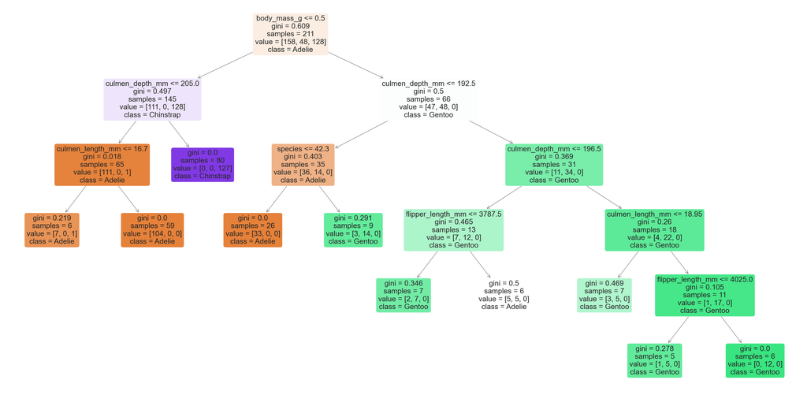

```python
# Plotting tree
get_dt(rf_best1)
```

```python
# Evaluation parameters
eval_mat(rf_best1)
```

```
Train Performance
0.9356223175965666
[[95 10  0]
 [ 5 45  0]
 [ 0  0 78]]
Test Performance
0.9306930693069307
[[37  3  1]
 [ 2 16  0]
 [ 1  0 41]]
```

### Importance of the variable in random forest

```python
par_rf = RandomForestClassifier(random_state=42, n_jobs=-1, max_depth=5, n_estimators = 100)
```

```python
par_rf.fit(X_train, y_train)
```

```
RandomForestClassifier(max_depth=5, n_jobs=-1, random_state=42)
```

```python
par_rf.feature_importances_
```

```
array([0.33245045, 0.21162901, 0.20495327, 0.11568387, 0.10752552,
       0.01987342, 0.00788445])
```

```python
imp_var = pd.DataFrame({
    'varname': X_train.columns,
    'IMP': par_rf.feature_importances_
})
imp_var
```

|  | varname | IMP |
| --- | --- | --- |
| 0 | culmen_length_mm | 0.332450 |
| 1 | culmen_depth_mm | 0.211629 |
| 2 | flipper_length_mm | 0.204953 |
| 3 | body_mass_g | 0.115684 |
| 4 | island_Dream | 0.107526 |
| 5 | island_Torgersen | 0.019873 |
| 6 | sex_MALE | 0.007884 |

```python
imp_var.sort_values(by= 'IMP', ascending=False)
```

|  | varname | IMP |
| --- | --- | --- |
| 0 | culmen_length_mm | 0.332450 |
| 1 | culmen_depth_mm | 0.211629 |
| 2 | flipper_length_mm | 0.204953 |
| 3 | body_mass_g | 0.115684 |
| 4 | island_Dream | 0.107526 |
| 5 | island_Torgersen | 0.019873 |
| 6 | sex_MALE | 0.007884 |

- By implemeting the random forest model on the Penguine dataset, we can observed thet for the classification of the species the culmen_length_mm, culmen_depth_mm, flipper_length_mm are the top 3 important parameters